# sweetalert as an R htmlwidget

Kent Russell

February 04, 2016

### Now in R as an htmlwidget

Looking at the Github stats below, I clearly am not the only one who loves sweetalert by [Tristan Edwards](http://tristanedwards.me).

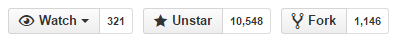

Since it is so useful and so beautiful, of course we need it in `R` as an [`htmlwidget`](http://htmlwidgets.org). Below are all the [demo examples](http://t4t5.github.io/sweetalert) from `sweetalert` recreated in R using the new [`sweetalertR`](https://github.com/timelyportfolio/sweetalertR) htmlwidget.

**Please note almost all of the HTML/JS/CSS should be directly attributed to the sweetalert author Tristan Edwards.**

# Sweet Alert

## A beautiful replacement for JavaScript’s “Alert”

### So… What does it do?

Here’s a comparison of a standard error message. The first one uses the built-in **alert**-function, while the second is using **sweetAlert**.

#### Normal alert

##### Code:

```
alert("Oops... Something went wrong!");
```

#### Sweet Alert

##### Code:

```r
# instead of copying the code from sweetalert examples
#  let's use R sweetalertR htmlwidgets
library(sweetalertR)

sweetalert(
  selector = '.showcase.sweet button',
    title = "Oops...",
  text = "Something went wrong!",
  type = "error"
)
```

[interactive chart not shown]

Pretty cool huh? SweetAlert automatically centers itself on the page and looks great no matter if you’re using a desktop computer, mobile or tablet. It’s even highly customizeable, as you can see below!

### More examples

In these examples, we will use the `sweetalert()` function from the R htmlwidget `sweetalertR` instead of `swal` or `sweetAlert` in JavaScript.

- A basic message

  ```r
  sweetalert(
    selector = 'ul.examples li.message button',
      text = "Here's a message!"
  )
  ```

[interactive chart not shown]

- A title with a text under

  ```r
  sweetalert(
    'ul.examples li.title-text button',
      title = "Here's a message!",
    text = "It's pretty, isn't it?"
  )
  ```

[interactive chart not shown]

- A success message!

  ```r
  sweetalert(
    'ul.examples li.success button',
      title = "Good job!",
    text = "You clicked the button!",
    type = "success"
  )
  ```

[interactive chart not shown]

- A warning message, with a function attached to the “Confirm”-button…

  ```r
  sweetalert(
    'ul.examples li.warning.confirm button',
      title = "Are you sure?",
      text = "You will not be able to recover this imaginary file!",
      type = "warning",
      showCancelButton = TRUE,
      confirmButtonColor = '#DD6B55',
      confirmButtonText = 'Yes, delete it!',
      closeOnConfirm = FALSE,
    evalFunction = '
  function(){
      swal("Deleted!", "Your imaginary file has been deleted!", "success")
  }
    '
  )
  ```

[interactive chart not shown]

- … and by passing a parameter, you can execute something else for “Cancel”.

  ```r
  sweetalert('ul.examples li.warning.cancel button',
      title = "Are you sure?",
      text = "You will not be able to recover this imaginary file!",
      type = "warning",
      showCancelButton = TRUE,
      confirmButtonColor = '#DD6B55',
      confirmButtonText = 'Yes, delete it!',
      cancelButtonText = "No, cancel plx!",
      closeOnConfirm = FALSE,
      closeOnCancel = FALSE,
      evalFunction = '
  function(isConfirm){
    if (isConfirm){
      swal("Deleted!", "Your imaginary file has been deleted!", "success")
    } else {
      swal("Cancelled", "Your imaginary file is safe  =)", "error")
    }
  }'
  )
  ```

[interactive chart not shown]

- A message with a custom icon

  ```r
  sweetalert('ul.examples li.custom-icon button',
      title = "Sweet!",
      text = "Here's a custom image.",
      imageUrl = 'images/thumbs-up.jpg'
  )
  ```

[interactive chart not shown]

- An HTML message

  ```r
  sweetalert('ul.examples li.message-html button',
      title = "HTML <small>Title</small>!",
      text = 'A custom <span style="color:#F8BB86">html<span> message.',
      html = TRUE
  )
  ```

[interactive chart not shown]

- A message with auto close timer

  ```r
  sweetalert(
    'ul.examples li.timer button',
      title = "Auto close alert!",
      text = "I will close in 2 seconds.",
      timer = 2000,
      showConfirmButton = FALSE
  )
  ```

[interactive chart not shown]

- A replacement for the “prompt” function

  ```r
  sweetalert('ul.examples li.input button',
      title = "An input!",
      text = 'Write something interesting: ',
      type = 'input',
      showCancelButton = TRUE,
      closeOnConfirm = FALSE,
      animation = "slide-from-top",
      inputPlaceholder = "Write something",
      evalFunction = '
  function(inputValue){
      if (inputValue === false) return false
      if (inputValue === "") {
          swal.showInputError("You need to write something!")
          return false
      }
      swal("Nice!", "You wrote: " + inputValue, "success")
  }
  '
  )
  ```

[interactive chart not shown]

- You can also change the theme of SweetAlert!

  ```r
  sweetalert('ul.examples li.theme button',
      title = "Themes!",
      text = "Here's the Twitter theme for SweetAlert!",
      confirmButtonText = "Cool!",
      customClass = 'twitter'
  )
  ```

[interactive chart not shown]

### Download & install

Install with devtools::install_github:

```
devtools::install_github("timelyportfolio/sweetalertR")
```

### Configuration

Here are the keys that you can use if you pass an object into sweetAlert:

| Argument | Default value | Description |
| --- | --- | --- |
| **title** | *null (required)* | The title of the modal. It can either be added to the object under the key “title” or passed as the first parameter of the function. |
| **text** | *null* | A description for the modal. It can either be added to the object under the key “text” or passed as the second parameter of the function. |
| **type** | *null* | The type of the modal. SweetAlert comes with 4 built-in types which will show a corresponding icon animation: “**warning**”, “**error**”, “**success**” and “**info”**. You can also set it as “**input*… |
| **allowEscapeKey** | *true* | If set to **true**, the user can dismiss the modal by pressing the Escape key. |
| **customClass** | *null* | A custom CSS class for the modal. It can be added to the object under the key “customClass”. |
| **allowOutsideClick** | *false* | If set to **true**, the user can dismiss the modal by clicking outside it. |
| **showCancelButton** | *false* | If set to **true**, a “Cancel”-button will be shown, which the user can click on to dismiss the modal. |
| **showConfirmButton** | *true* | If set to **false**, the “OK/Confirm”-button will be hidden. Make sure you set a timer or set allowOutsideClick to true when using this, in order not to annoy the user. |
| **confirmButtonText** | *“OK”* | Use this to change the text on the “Confirm”-button. If showCancelButton is set as true, the confirm button will automatically show “Confirm” instead of “OK”. |
| **confirmButtonColor** | *“#AEDEF4”* | Use this to change the background color of the “Confirm”-button (must be a HEX value). |
| **cancelButtonText** | *“Cancel”* | Use this to change the text on the “Cancel”-button. |
| **closeOnConfirm** | *true* | Set to *false* if you want the modal to stay open even if the user presses the “Confirm”-button. This is especially useful if the function attached to the “Confirm”-button is another SweetAlert. |
| **closeOnCancel** | *true* | Same as closeOnConfirm, but for the cancel button. |
| **imageUrl** | *null* | Add a customized icon for the modal. Should contain a string with the path to the image. |
| **imageSize** | *“80x80”* | If imageUrl is set, you can specify imageSize to describes how big you want the icon to be in px. Pass in a string with two values separated by an “x”. The first value is the width, the second is the … |
| **timer** | *null* | Auto close timer of the modal. Set in ms (milliseconds). |
| **html** | *false* | If set to true, will not escape title and text parameters. (Set to false if you’re worried about XSS attacks.) |
| **animation** | *true* | If set to **false**, the modal’s animation will be disabled. |
| **inputType** | *“text”* | Change the type of the input field when using **type: “input”** (this can be useful if you want users to type in their password for example). |
| **inputPlaceholder** | *null* | When using the input-type, you can specify a placeholder to help the user. |
| **inputValue** | *null* | Specify a default text value that you want your input to show when using **type: “input”** |

### Contribute

SweetAlert was created by [Tristan Edwards](http://tristanedwards.me), you can follow him on [Twitter](https://twitter.com/t4t5) or [Dribbble](https://dribbble.com/tristanedwards) for updates and other cool projects!

Feel free to fork SweetAlert on [GitHub](https://github.com/t4t5/sweetalert) if you have any features that you want to add!

[`sweetalertR`](https://github.com/timelyportfolio/sweetalertR) was created by Kenton Russell to wrap SweetAlert and make it available in `R` as an `htmlwidget`.